# 04-Juvenile-data-analysis-QuantSeq2020

Laura H Spencer

1/24/2021

```r
getwd()
```

```
## [1] "/Volumes/Bumblebee/O.lurida_QuantSeq-2020/notebooks"
```

### Load libraries and source scripts

```r
source("../references/biostats.R")

list.of.packages <- c("DESeq2", "RCurl", "tidyverse", "vegan", "pheatmap", "pastecs", "factoextra", "FactoMineR", "RColorBrewer", "tibble", "reshape2", "plotly", "clipr") #add new libraries here
new.packages <- list.of.packages[!(list.of.packages %in% installed.packages()[,"Package"])]
if(length(new.packages)) install.packages(new.packages)

# Load all libraries
lapply(list.of.packages, FUN = function(X) {
  do.call("require", list(X))
})
```

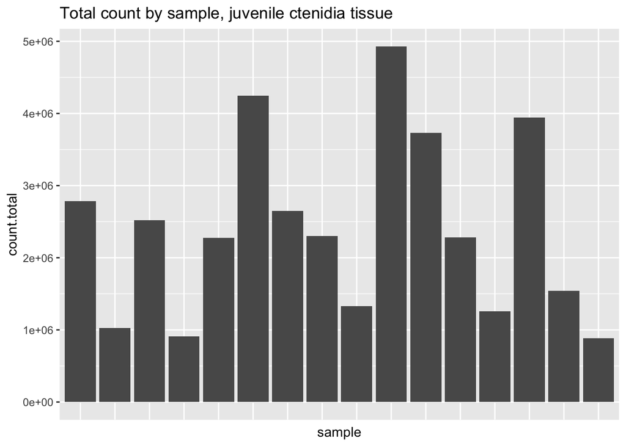

```r
load(file = "../results/gene-counts-filtered") #object = counts.filtered
load(file="../raw-data/key")

#ggplotly(
ggplot(data = data.frame(colSums(counts.filtered)) %>%
                  dplyr::rename(count.total = 1) %>%
                  rownames_to_column(var="sample") %>%
                  filter(grepl("_juvenile", sample))) +
           geom_bar(aes(x=sample, y=count.total), stat = "identity") + ggtitle("Total count by sample, juvenile ctenidia tissue") +
             theme(axis.text.x = element_blank(), axis.ticks.x = element_blank())#)
```

### Load transformed counts object

```r
load(file = "../results/gene-counts-trans") #object = counts.t
```

#### If warranted, check out sample ke

```r
key %>% filter(stage=="juvenile") %>% select(sample, population, temp.parent, pCO2.parent)
```

```
##    sample  population temp.parent pCO2.parent
## 1     137   Dabob Bay           6     Ambient
## 2     139   Dabob Bay           6     Ambient
## 3     140   Dabob Bay           6     Ambient
## 4     141   Dabob Bay           6     Ambient
## 5     156 Fidalgo Bay           6     Ambient
## 6     159 Fidalgo Bay           6     Ambient
## 7     161 Fidalgo Bay           6     Ambient
## 8     162 Fidalgo Bay           6     Ambient
## 9     168   Dabob Bay           6        High
## 10    169   Dabob Bay           6        High
## 11    171   Dabob Bay           6        High
## 12    172   Dabob Bay           6        High
## 13    181 Fidalgo Bay           6        High
## 14    183 Fidalgo Bay           6        High
## 15    184 Fidalgo Bay           6        High
## 16    185 Fidalgo Bay           6        High
```

### Extract juvenile samples only

```r
counts.t.juv <- as.data.frame(counts.t[grepl(".juvenile", rownames(counts.t)), ])
counts.t.juv[,1:3] #take a peak at the resulting dataframe
```

```
##              OLUR_00020575 OLUR_00006628 OLUR_00032161
## 137_juvenile             1            46             0
## 139_juvenile             0            11             0
## 140_juvenile             1            33             3
## 141_juvenile             0             3             0
## 156_juvenile             0             8             0
## 159_juvenile             0            10             0
## 161_juvenile             3             4             0
## 162_juvenile             0             3             0
## 168_juvenile             0            12             0
## 169_juvenile             1            61             0
## 171_juvenile             0            42             0
## 172_juvenile             2            22             0
## 181_juvenile             0             8             0
## 183_juvenile             4             8             0
## 184_juvenile             1            12             0
## 185_juvenile             0            14             0
```

## Optional

### Pre-filtering - remove rows (genes) with less than a total of 10 reads (across all samples) (why?)

```r
keep <- colSums(counts.t.juv) >= 10
counts.ts.juv <- counts.t.juv[,keep]
print(paste("# genes remaining after pre-filtering:", ncol(counts.ts.juv)))
```

```
## [1] "# genes remaining after pre-filtering: 27224"
```

```r
print(paste("# of genes dropped:", ncol(counts.t.juv) - ncol(counts.ts.juv), sep=" "))
```

```
## [1] "# of genes dropped: 4986"
```

### How many genes were identified in each sample?

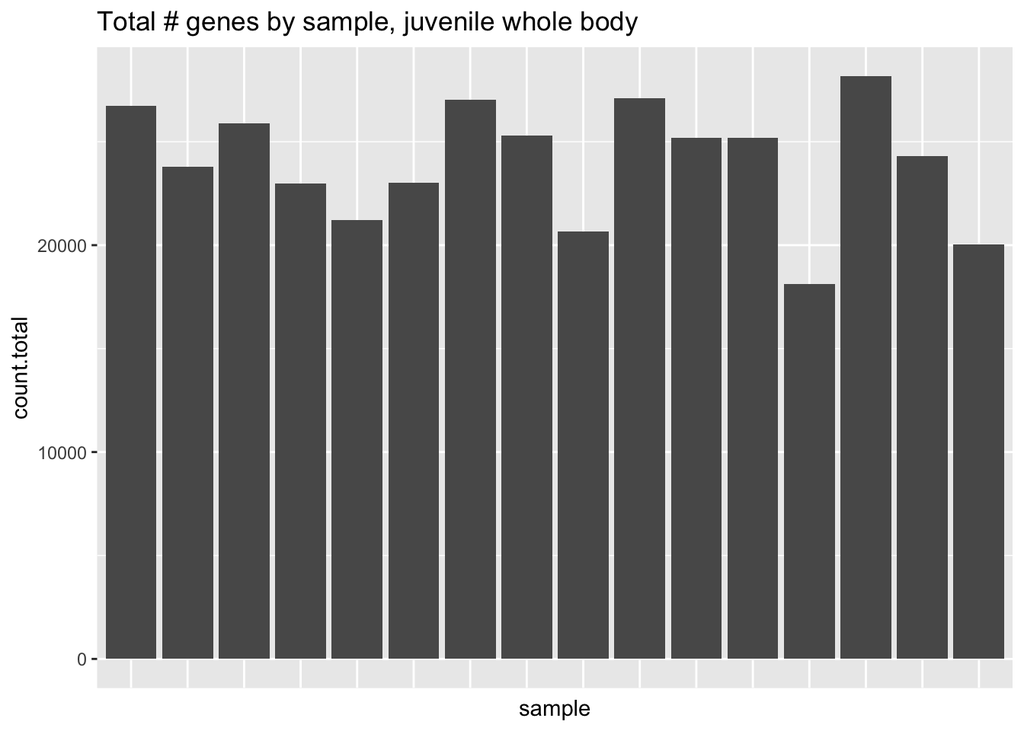

```r
#ggplotly(
ggplot(data = data.frame(rowSums(counts.t.juv != 0)) %>%
                  dplyr::rename(count.total = 1) %>%
                  rownames_to_column(var="sample") %>%
                  filter(grepl("_juvenile", sample))) +
           geom_bar(aes(x=sample, y=count.total), stat = "identity") + ggtitle("Total # genes by sample, juvenile whole body") +
             theme(axis.text.x = element_blank(), axis.ticks.x = element_blank())#)
```

## Use foa.plots to visualize data a bit:

### What is the mean abundance of each gene when it occurs (not averaging zeros for samples where it is absent)?

- The **fifth plot is an ECDF of gene mean abundance.** X-axis is samples, ranked from 1-n in terms of mean gene abundance.

### Is the mean abundance of genes correlated with the number of samples they occur in?

- The **sixth plot is a scatter plot of frequency of occurrence against mean abundance**. Is there any apparent relationship between the two? Are the widespread genes also generally more abundant? Are there many widespread genes that occur at low abundance? Conversely, are there genes much less widespread, but abundant where they occur?

### Is the total abundance of gene in a sample correlated with the number of gene in a sample? To answer this question, first it is instructive to look at the number of gene per sample.

- The **eighth plot depicts the ECDF of sample richness.** Are there any interesting patterns? For example, do most samples support an average number of gene, while only a few samples supporting either very few or very many gene? Or is the pattern different?

### Second, what is the pattern in the distribution of sample total abundance?

- The **ninth plot is the ECDF of total sample abundance.** How does it compare to the ECDF of sample richness?

### Finally, to answer the question on the relation between total abundance and number of gene/sample …

- The **last plot is a scatter plot of the two variables.** Is there is relationship between the *number of genes per sample and the total abundance?* Do gene-rich samples generally have a greater total abundance of those genes as well?

```r
# note: you'll need to press return in the console for all plots
#foa.plots(counts.ts.juv)
```

### Merge sample key info to count data, then sort, and generate heat map for initial inspection by treatment

```r
# merge count data with sample key, reset row names as sample names, and arrange by infection, then temperature, then day
counts.tsk.juv <- merge(x=key, by.x="sample_stage", y=counts.ts.juv, by.y="row.names") %>%
  arrange(stage, population, pCO2.parent)  %>% column_to_rownames(var="sample_stage")

head(counts.tsk.juv[1:24]) #check out results of merge/arrange
```

```
##              lane sample RNA.conc RNA.ng endpoint.RFU pcr.cycles prep.batch
## 137_juvenile    1    137      111    496            2         15          7
## 139_juvenile    1    139       12    500           10         14          7
## 140_juvenile    1    140       28    500           16         15          7
## 141_juvenile    1    141       35    500           11         15          7
## 168_juvenile    1    168       93    445           14         16          7
## 169_juvenile    1    169      105    478            3         16          7
##                    species    stage                 tissue DNA.ng bioan.mean.bp
## 137_juvenile Ostrea lurida juvenile whole body, individual   5.20            28
## 139_juvenile Ostrea lurida juvenile whole body, individual  13.30            21
## 140_juvenile Ostrea lurida juvenile whole body, individual   7.62            25
## 141_juvenile Ostrea lurida juvenile whole body, individual  23.60            28
## 168_juvenile Ostrea lurida juvenile whole body, individual  15.90            23
## 169_juvenile Ostrea lurida juvenile whole body, individual   3.68            24
##              index.no index.seq population temp.parent pCO2.parent
## 137_juvenile     7090    CCTGCT  Dabob Bay           6     Ambient
## 139_juvenile     7081    GCAGCC  Dabob Bay           6     Ambient
## 140_juvenile     7091    GCGCTG  Dabob Bay           6     Ambient
## 141_juvenile     7088    AGACCA  Dabob Bay           6     Ambient
## 168_juvenile     7094    AGAATC  Dabob Bay           6        High
## 169_juvenile     7092    GAACCT  Dabob Bay           6        High
##              larval.sample filename OLUR_00020575 OLUR_00006628 OLUR_00011450
## 137_juvenile          <NA>      137             1            46            29
## 139_juvenile          <NA>      139             0            11             9
## 140_juvenile          <NA>      140             1            33            29
## 141_juvenile          <NA>      141             0             3            14
## 168_juvenile          <NA>      168             0            12            35
## 169_juvenile          <NA>      169             1            61            77
##              OLUR_00018391 OLUR_00011614
## 137_juvenile             3             3
## 139_juvenile             1             2
## 140_juvenile             4             5
## 141_juvenile             1             6
## 168_juvenile             1             0
## 169_juvenile             9             4
```

```r
#counts.tsk.juv %>% dplyr::select(starts_with("OLUR")) #this is code to get only the gene columns
```

### Generate heat map of counts before DESeq processing / analysis, save to file

NOTE: scale=“column” b/c range of counts is so huge, so counts have been scaled

```r
pheatmap(data.matrix(counts.tsk.juv %>% dplyr::select(starts_with("OLUR"))), Rowv=NA, Colv=NA, na.rm = TRUE, xlab = NA,
                     show_colnames =FALSE, cluster_cols = FALSE, cluster_rows = TRUE,
                     scale="column", color=c("dodgerblue3", "goldenrod1"),
                     main = "Oly juvenile ctendia gene counts", annotation_row=counts.tsk.juv[,c("population", "pCO2.parent")],
         filename = "../results/heatmap-juvenile-counts.png")
```

Resulting heat map is located in results/ directory:

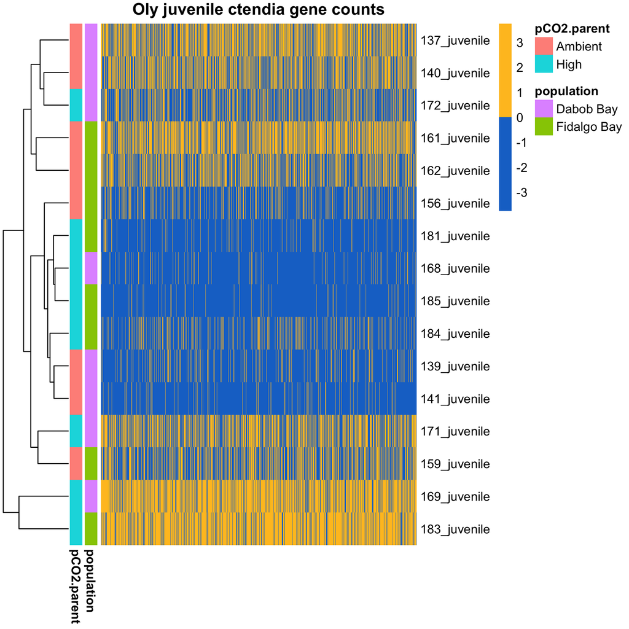

# Analysis in DESeq2

### Reformat for DESeq, ensure correct sample order for

NOTE: It is absolutely critical that the **columns of the count matrix** and the **rows of the column data (information about samples)** are in the same order. DESeq2 will not make guesses as to which column of the count matrix belongs to which row of the column data, these must be provided to DESeq2 already in consistent order.

```r
all(rownames(counts.tsk.juv) == counts.tsk.juv %>% dplyr::select(starts_with("OLUR")) %>% t() %>% colnames()) #check that rownames of untransformed matrix match column names of transformed matrix. Should print 'TRUE'
```

```
## [1] TRUE
```

# Generate DESeq datasets with various treatment comparisons

```r
#counts.DESeq <- counts.tsk.juv[-which(rownames(counts.tsk.juv) %in% "571_larvae"), grepl("OLUR", colnames(counts.tsk.juv))] %>% t()
#key.DESeq <- counts.tsk.juv[-which(rownames(counts.tsk.juv) %in% "571_larvae"),c("population", "pCO2.parent")]

dds.juv <- DESeqDataSetFromMatrix(countData = counts.tsk.juv[,grepl("OLUR", colnames(counts.tsk.juv))] %>% t(),
                              colData = counts.tsk.juv[,c("population", "pCO2.parent")] ,
                              design = ~ population + pCO2.parent)
```

```
## factor levels were dropped which had no samples
```

```
##   Note: levels of factors in the design contain characters other than
##   letters, numbers, '_' and '.'. It is recommended (but not required) to use
##   only letters, numbers, and delimiters '_' or '.', as these are safe characters
##   for column names in R. [This is a message, not an warning or error]
```

# Visualize data via PCAs and heat maps

## Transform data

- Here we transform counts using a variance stabilizing transformation (VST), since the rlog transformation threw an error and suggested using VST.
- Here we use `blind=FALSE` b/c we are interested in differences explained by experimental design, and may wish to use this transformed data in downstream analyses.

```r
vsd.juv <- varianceStabilizingTransformation(dds.juv, blind=FALSE)
```

```
##   Note: levels of factors in the design contain characters other than
##   letters, numbers, '_' and '.'. It is recommended (but not required) to use
##   only letters, numbers, and delimiters '_' or '.', as these are safe characters
##   for column names in R. [This is a message, not an warning or error]
```

## Visualize sample clustering via PCA (after transformation)

NOTE: Hover over points to see the sample numbers

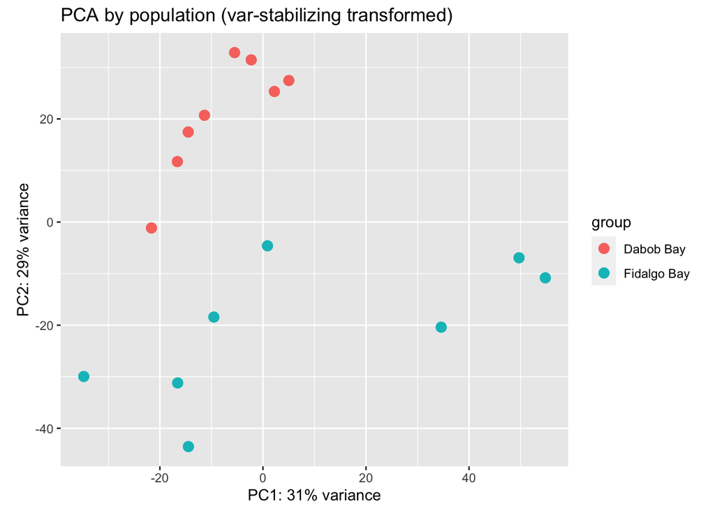

```r
# PCA with points color coded by population
#ggplotly(
plotPCA(vsd.juv, intgroup="population") +
           ggtitle("PCA by population (var-stabilizing transformed)") + geom_point(size=3, aes(text=colnames(vsd.juv)))#, tooltip = "text")
```

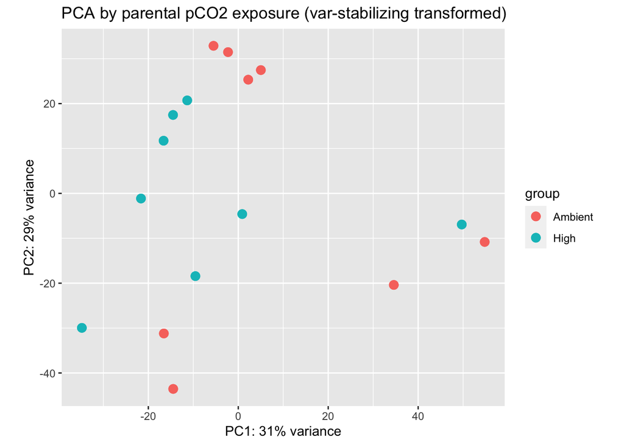

```r
# PCA with points color coded by parental pCO2 exposure
#ggplotly(
plotPCA(vsd.juv, intgroup="pCO2.parent") +
           ggtitle("PCA by parental pCO2 exposure (var-stabilizing transformed)") + geom_point(size=3, aes(text=colnames(vsd.juv)))#, tooltip = "text")
```

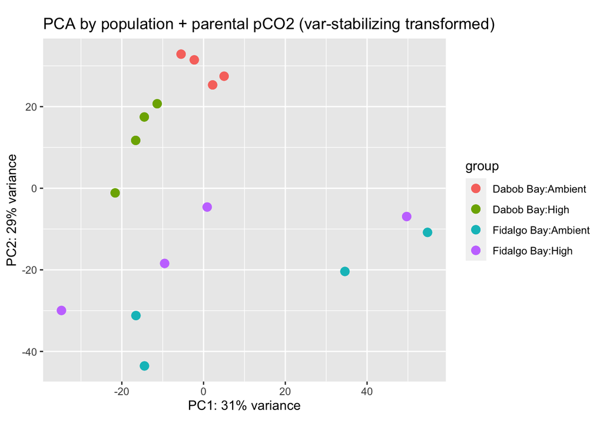

```r
# PCA with points color coded by tissue and pco2 factors
#ggplotly(
  plotPCA(vsd.juv, intgroup=c("population","pCO2.parent")) +
           ggtitle("PCA by population + parental pCO2 (var-stabilizing transformed)") + geom_point(size=3, aes(text=colnames(vsd.juv)))#, tooltip = "text")
```

### Generate heat maps before & after transformation

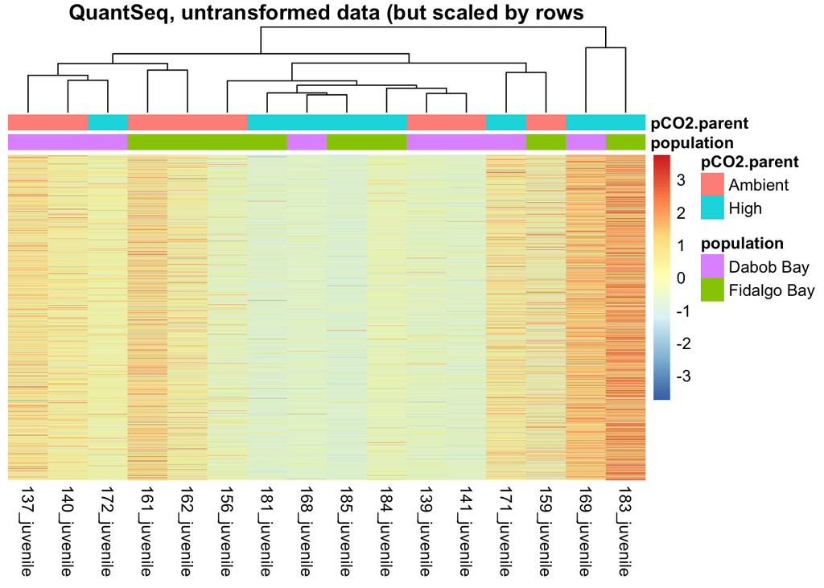

```r
# extract treatment info from VSD transformation
vsd.juv.df <- as.data.frame(colData(vsd.juv)[,c("population", "pCO2.parent")])

# generate heatmap from untransformed counts
pheatmap(counts(dds.juv), cluster_rows=FALSE, show_rownames=FALSE,
         cluster_cols=T, annotation_col=vsd.juv.df, scale = "row", main="QuantSeq, untransformed data (but scaled by rows")
```

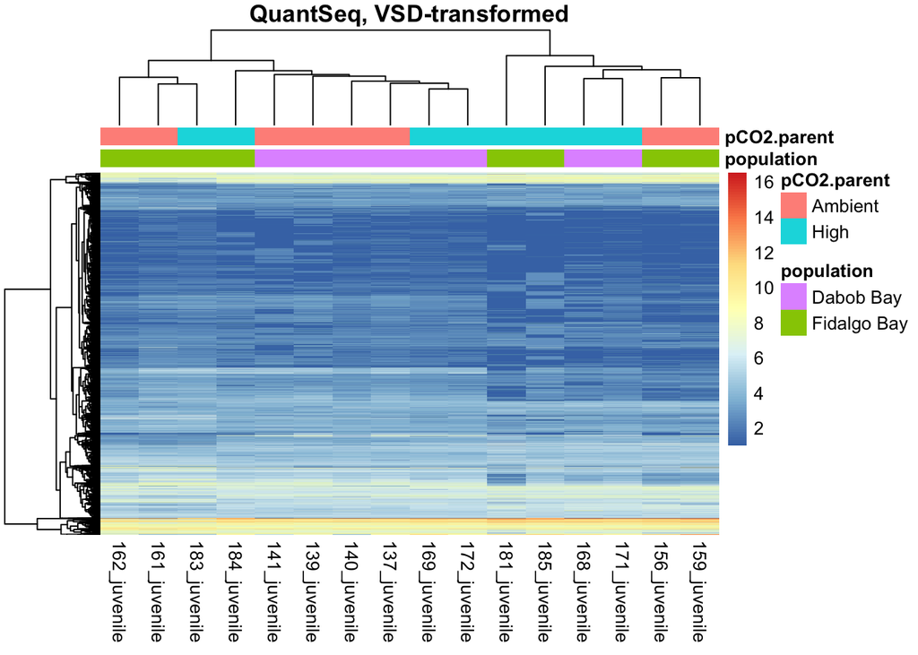

```r
# generate heatmap from VSD counts
pheatmap(assay(vsd.juv), cluster_rows=T, show_rownames=FALSE,
         cluster_cols=T, annotation_col=vsd.juv.df, main = "QuantSeq, VSD-transformed")
```

### Heatmap of the sample-to-sample distances

Another use of the transformed data is sample clustering. Here, we apply the dist function to the transpose of the transformed count matrix to get sample-to-sample distances.

A heatmap of this distance matrix gives us an overview over similarities and dissimilarities between samples. We have to provide a hierarchical clustering hc to the heatmap function based on the sample distances, or else the heatmap function would calculate a clustering based on the distances between the rows/columns of the distance matrix.

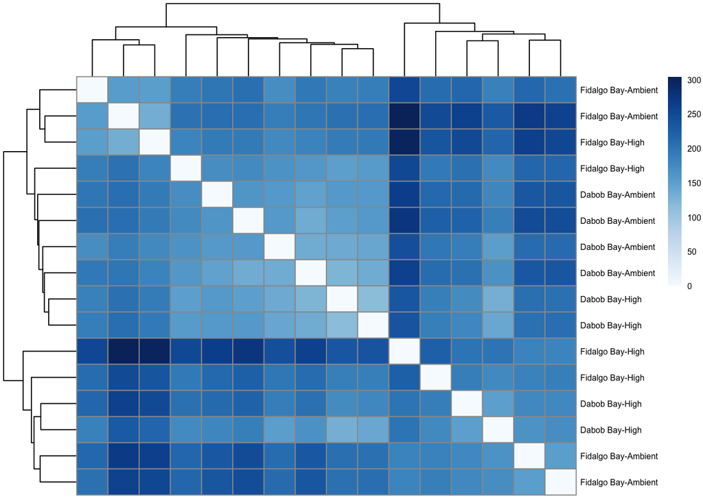

```r
colors <- colorRampPalette(rev(brewer.pal(9, "Blues")) )(255)

sampleDists <- dist(t(assay(vsd.juv)))
sampleDistMatrix <- as.matrix(sampleDists)

# Here we show pCO2.parent + population
rownames(sampleDistMatrix) <- paste(vsd.juv$population, vsd.juv$pCO2.parent, sep="-") #set row names
colnames(sampleDistMatrix) <- NULL
pheatmap(sampleDistMatrix,
         clustering_distance_rows=sampleDists,
         clustering_distance_cols=sampleDists,
         col=rev(colors), fontsize = 6)
```

## Differential Expression Analysis - multifactor design

### Run the function `DESeq` to assess differential expression

```r
dds.juv.DESeq <- DESeq(dds.juv)
```

[output not shown]

[output not shown]

[output not shown]

### Check out DESeq object design and treatments

```r
colData(dds.juv.DESeq) # check out treatments
```

```
## DataFrame with 16 rows and 3 columns
##               population pCO2.parent        sizeFactor
##                 <factor>    <factor>         <numeric>
## 137_juvenile   Dabob Bay     Ambient  1.51544922064543
## 139_juvenile   Dabob Bay     Ambient 0.566597399569324
## 140_juvenile   Dabob Bay     Ambient  1.40356145984149
## 141_juvenile   Dabob Bay     Ambient 0.501627420129038
## 168_juvenile   Dabob Bay        High 0.574432453852376
## ...                  ...         ...               ...
## 162_juvenile Fidalgo Bay     Ambient  1.36153939101489
## 181_juvenile Fidalgo Bay        High 0.511062452364415
## 183_juvenile Fidalgo Bay        High  2.45119729718864
## 184_juvenile Fidalgo Bay        High 0.791393959019471
## 185_juvenile Fidalgo Bay        High 0.385294631445447
```

```r
design(dds.juv.DESeq)
```

```
## ~population + pCO2.parent
```

# Juveniles: Differential Gene Expression Analysis by *parental pCO2 exposure* (both populations combined)

```r
print("Comparison: parental pCO2 - All populations")
```

```
## [1] "Comparison: parental pCO2 - All populations"
```

```r
summary(res.juv.pco2 <- results(dds.juv.DESeq, contrast=c("pCO2.parent", "Ambient", "High"), alpha=0.05))
```

```
##
## out of 27224 with nonzero total read count
## adjusted p-value < 0.05
## LFC > 0 (up)       : 12, 0.044%
## LFC < 0 (down)     : 17, 0.062%
## outliers [1]       : 100, 0.37%
## low counts [2]     : 2109, 7.7%
## (mean count < 1)
## [1] see 'cooksCutoff' argument of ?results
## [2] see 'independentFiltering' argument of ?results
```

```r
paste("No. of genes differentially expressed (padj<0.05) by pCO2, juvenile ctendia, comparison across both FB and DB pops:",  sum(res.juv.pco2$padj < 0.05, na.rm=TRUE))
```

```
## [1] "No. of genes differentially expressed (padj<0.05) by pCO2, juvenile ctendia, comparison across both FB and DB pops: 29"
```

```r
print(diffex.juv <- subset(res.juv.pco2, padj < 0.05)) #extract stats for genes that are diff. expressed among parental pCO2, all pops combined
```

```
## log2 fold change (MLE): pCO2.parent Ambient vs High
## Wald test p-value: pCO2.parent Ambient vs High
## DataFrame with 29 rows and 6 columns
##                       baseMean    log2FoldChange             lfcSE
##                      <numeric>         <numeric>         <numeric>
## OLUR_00009516 29.7094253756195 -2.00158026133413 0.476161298877608
## OLUR_00009517  461.35397293624 -2.17029923098166 0.513726472034838
## OLUR_00016228 20.6588427661538 -1.20688276279899 0.279046027840402
## OLUR_00022534 13.6544261088583  1.82223775258568 0.395451659310014
## OLUR_00005720 132.526087602957  1.43380031555088 0.334303899978309
## ...                        ...               ...               ...
## OLUR_00015978 14.9073197669646 -2.56324623554949  0.57503363821733
## OLUR_00030565 12.6829518223621 -1.78788766906529 0.415093496849986
## OLUR_00012774 530.279188494975 -6.67480285871683  1.29467271496944
## OLUR_00003122 2007.07553335835 -3.07807028206124  0.76506385567757
## OLUR_00022327 492.106131375935 -3.93333368761215 0.835262585268392
##                            stat               pvalue                padj
##                       <numeric>            <numeric>           <numeric>
## OLUR_00009516 -4.20357611181797 2.62730750778688e-05  0.0312962368129947
## OLUR_00009517 -4.22462019989984  2.3934407934868e-05  0.0299359607245361
## OLUR_00016228 -4.32503115037802 1.52510309762797e-05  0.0272503242765455
## OLUR_00022534     4.60799116576 4.06577933284778e-06  0.0101705470011187
## OLUR_00005720  4.28891291918494 1.79549746273079e-05  0.0274555652437637
## ...                         ...                  ...                 ...
## OLUR_00015978 -4.45755876733725 8.28983147778369e-06  0.0175208260552874
## OLUR_00030565 -4.30719267498289 1.65339581105926e-05  0.0274555652437637
## OLUR_00012774 -5.15559089300372 2.52832362132064e-07 0.00210820051291119
## OLUR_00003122 -4.02328545417321 5.73918656649239e-05  0.0495054317106231
## OLUR_00022327 -4.70909838053894 2.48814961637869e-06 0.00910646801501654
```

```r
diffex.juv.counts <- subset(counts(dds.juv.DESeq), rownames(dds.juv.DESeq) %in% rownames(diffex.juv))
diffex.juv.counts <- diffex.juv.counts[,subset(key, stage=="juvenile")$sample_stage]
```

## Heatmap of differentially expressed genes, both populations

```r
dds.juv.df <- as.data.frame(colData(dds.juv)[,c("population", "pCO2.parent")])
dds.juv.df <- dds.juv.df[match(rownames(dds.juv.df), colnames(diffex.juv.counts)),]
all(colnames(diffex.juv.counts) == rownames(dds.juv.df)) #double check that samples are still in same order
```

```
## [1] TRUE
```

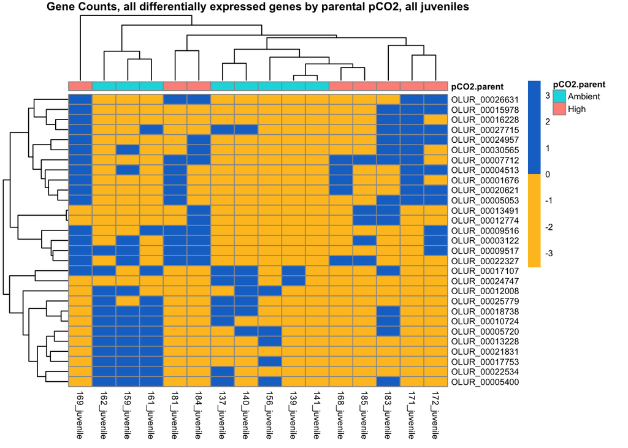

```r
pheatmap(diffex.juv.counts, cluster_rows=T, show_rownames=T, cluster_columns=T, na.rm=TRUE, scale="row", main = "Gene Counts, all differentially expressed genes by parental pCO2, all juveniles", annotation_col=dds.juv.df[c(2)], color=rev(c("dodgerblue3", "goldenrod1")), fontsize = 7)
```

# Juveniles: Differential Gene Expression Analysis by *parental pCO2 exposure within population*

```r
# Add factor that defines interaction group
dds.juv.DESeq$group <- factor(paste0(dds.juv.DESeq$population, dds.juv.DESeq$pCO2.parent))
design(dds.juv.DESeq) <- ~ group
```

```
##   Note: levels of factors in the design contain characters other than
##   letters, numbers, '_' and '.'. It is recommended (but not required) to use
##   only letters, numbers, and delimiters '_' or '.', as these are safe characters
##   for column names in R. [This is a message, not an warning or error]
```

```r
dds.juv.DESeq <- DESeq(dds.juv.DESeq)
```

```
## found already estimated dispersions, replacing these
```

[output not shown]

[output not shown]

## Extract differential expression results / comparisons among different factors

Create results objects, but summary of results are also shown

NOTE: can only compare two treatments at a time

```r
# Here are all the possible contrasts I can make
#levels(dds.multi.DESeq$group)

print("Comparison: parental pCO2 - Fidalgo Bay")
```

```
## [1] "Comparison: parental pCO2 - Fidalgo Bay"
```

```r
summary(res.juv.FB <- results(dds.juv.DESeq, contrast=c("group", "Fidalgo BayHigh", "Fidalgo BayAmbient"), alpha=0.05))
```

```
##
## out of 27224 with nonzero total read count
## adjusted p-value < 0.05
## LFC > 0 (up)       : 20, 0.073%
## LFC < 0 (down)     : 17, 0.062%
## outliers [1]       : 50, 0.18%
## low counts [2]     : 1056, 3.9%
## (mean count < 1)
## [1] see 'cooksCutoff' argument of ?results
## [2] see 'independentFiltering' argument of ?results
```

```r
print("Comparison: parental pCO2 - Dabob Bay")
```

```
## [1] "Comparison: parental pCO2 - Dabob Bay"
```

```r
summary(res.juv.DB <- results(dds.juv.DESeq, contrast=c("group", "Dabob BayHigh", "Dabob BayAmbient"), alpha=0.05))
```

```
##
## out of 27224 with nonzero total read count
## adjusted p-value < 0.05
## LFC > 0 (up)       : 13, 0.048%
## LFC < 0 (down)     : 26, 0.096%
## outliers [1]       : 50, 0.18%
## low counts [2]     : 4749, 17%
## (mean count < 2)
## [1] see 'cooksCutoff' argument of ?results
## [2] see 'independentFiltering' argument of ?results
```

```r
paste("No. of genes differentially expressed (padj<0.05) by parental pCO2, Fidalgo Bay juvenile ctenidia:",  sum(res.juv.FB$padj < 0.05, na.rm=TRUE))
```

```
## [1] "No. of genes differentially expressed (padj<0.05) by parental pCO2, Fidalgo Bay juvenile ctenidia: 37"
```

```r
paste("No. of genes differentially expressed (padj<0.05) by parental pCO2, Dabob Bay juvenile ctenidia:",  sum(res.juv.DB$padj < 0.05, na.rm=TRUE))
```

```
## [1] "No. of genes differentially expressed (padj<0.05) by parental pCO2, Dabob Bay juvenile ctenidia: 39"
```

## Extract stats for significantly different genes for each comparison

```r
diffex.juv.FB <- subset(res.juv.FB, padj < 0.05)
diffex.juv.DB <- subset(res.juv.DB, padj < 0.05)
```

## Extract counts for differentially expressed genes for each comparison

```r
diffex.juv.FB.counts <- subset(counts(dds.juv.DESeq), rownames(dds.juv.DESeq) %in% rownames(diffex.juv.FB))
diffex.juv.FB.counts <- diffex.juv.FB.counts[,subset(key, stage=="juvenile" & population=="Fidalgo Bay")$sample_stage]

diffex.juv.DB.counts <- subset(counts(dds.juv.DESeq), rownames(dds.juv.DESeq) %in% rownames(diffex.juv.DB))
diffex.juv.DB.counts <- diffex.juv.DB.counts[,subset(key, stage=="juvenile" & population=="Dabob Bay")$sample_stage]
```

# generate heatmap with differentially expressed genes within FB

```r
dds.juv.df.FB <- as.data.frame(colData(dds.juv)[colData(dds.juv)$population=="Fidalgo Bay",c("population", "pCO2.parent")])
dds.juv.df.FB <- dds.juv.df.FB[match(rownames(dds.juv.df.FB), colnames(diffex.juv.FB.counts)),]
all(colnames(diffex.juv.FB.counts) == rownames(dds.juv.df.FB)) #double check that samples are still in same order
```

```
## [1] TRUE
```

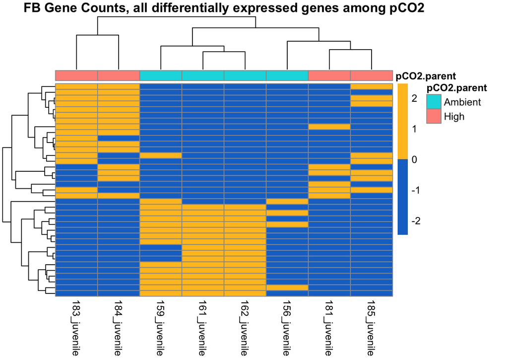

```r
pheatmap(diffex.juv.FB.counts, cluster_rows=T, show_rownames=FALSE, cluster_columns=T, na.rm=TRUE, scale="row", main = "FB Gene Counts, all differentially expressed genes among pCO2", annotation_col=dds.juv.df.FB[2], color=c("dodgerblue3", "goldenrod1"))
```

# generate heatmap with differentially expressed genes within DB

```r
dds.juv.df.DB <- as.data.frame(colData(dds.juv)[colData(dds.juv)$population=="Dabob Bay",c("population", "pCO2.parent")])
dds.juv.df.DB <- dds.juv.df.DB[match(rownames(dds.juv.df.DB), colnames(diffex.juv.DB.counts)),]
all(colnames(diffex.juv.DB.counts) == rownames(dds.juv.df.DB)) #double check that samples are still in same order
```

```
## [1] TRUE
```

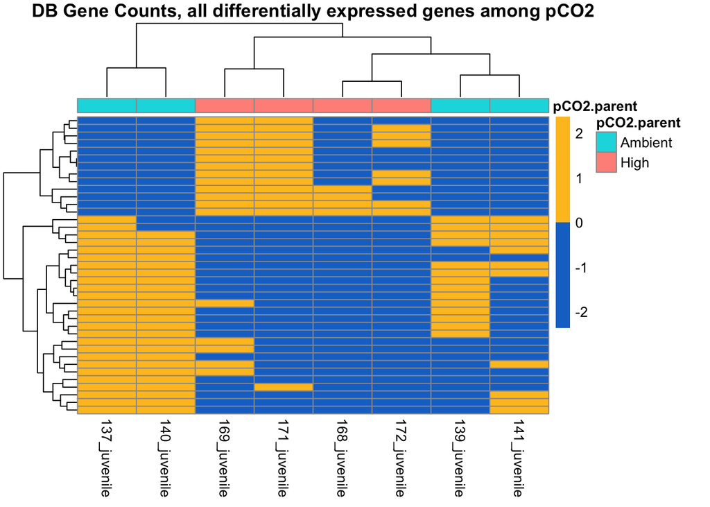

```r
pheatmap(diffex.juv.DB.counts, cluster_rows=TRUE, show_rownames=FALSE, cluster_columns=T, na.rm=TRUE, scale="row", main = "DB Gene Counts, all differentially expressed genes among pCO2", annotation_col=dds.juv.df.DB[2], color=c("dodgerblue3", "goldenrod1"))
```

## Extract genes that are differentially expressed in Juveniles between parental pCO2 in both cohorts

```r
Reduce(intersect, list(rownames(diffex.juv.FB),rownames(diffex.juv.DB)))
```

```
## [1] "OLUR_00005742"
```

### Here we plot the 1 genes that’s differentially expressed among parental pCO2 in both cohorts (OLUR_00005742)

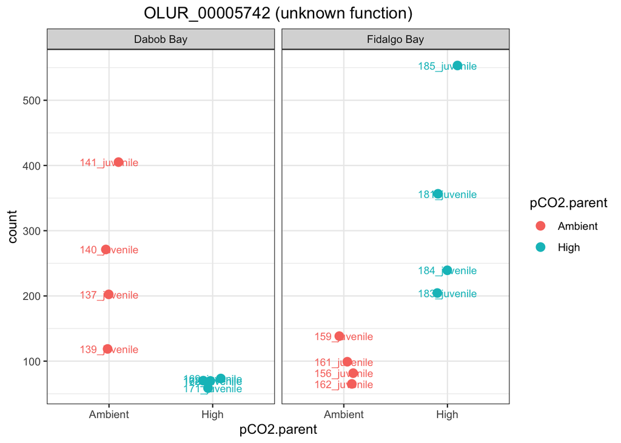

```r
a <-  plotCounts(dds.juv.DESeq, gene="OLUR_00005742", intgroup=c("population", "pCO2.parent"), returnData = TRUE)
ggplot(a %>% rownames_to_column("sample"),
       aes(x=pCO2.parent, y=count, color=pCO2.parent, label=sample)) +
  #geom_boxplot() +
  geom_point(size=3, position=position_jitter(w = 0.1,h = 0)) +
    geom_text(size=3) +
    theme_bw() +
    ggtitle("OLUR_00005742 (unknown function)") +
    theme(plot.title = element_text(hjust = 0.5)) +
  facet_wrap(~population)
```

## Plot gene counts for differentially expressed genes

It can also be useful to examine the counts of reads for a single gene across the groups. A simple function for making this plot is **`plotCounts`, which normalizes counts by sequencing depth and adds a pseudocount of 1/2 to allow for log scale plotting.** The counts are grouped by the variables in intgroup, where more than one variable can be specified. Here we specify the gene which had the smallest p value from the results table created above. You can select the gene to plot by rowname or by numeric index.

### Here we plot the 37 genes differentially expressed between FB cohorts whose parents were exposed to high pCO2 and not

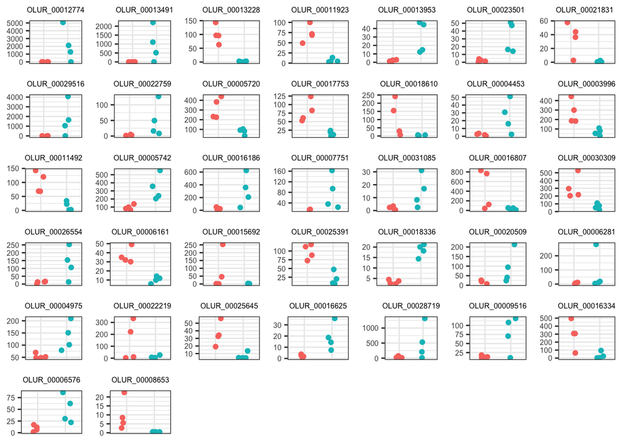

```r
juv.FB.p05.names <-rownames(diffex.juv.FB[order(diffex.juv.FB$padj),])
count_plots.juv.FB = list()
#plot the 37 genes with lowest p-values
for (i in 1:37) {
a <-  plotCounts(dds.juv.DESeq, gene=juv.FB.p05.names[i], intgroup=c("population", "pCO2.parent"), returnData = TRUE)
b <- ggplot(subset(a, population=="Fidalgo Bay") %>% rownames_to_column("sample") %>%
              mutate(sample=gsub("_juvenile", "", sample)),
       aes(x=pCO2.parent, y=count, color=pCO2.parent, label=sample)) +
  geom_point(position=position_jitter(w = 0.2,h = 0)) +
    #geom_text(size=3) +
    theme_bw() +
    ggtitle(juv.FB.p05.names[i]) +
    theme(plot.title = element_text(hjust = 0.5, size = 6), axis.text.x = element_blank(),
          axis.text.y = element_text(size=6),
          axis.title = element_blank(), axis.ticks.x = element_blank(), legend.position = "none")
count_plots.juv.FB[[i]] <- b
}

library(cowplot)
plot_grid(plotlist=count_plots.juv.FB) #plot them in a grid
```

```r
#count_plots.juv.FB #plot them all individually
```

### Here we plot the 39 genes differentially expressed between DABOB BAY cohorts whose parents were exposed to high pCO2 and not

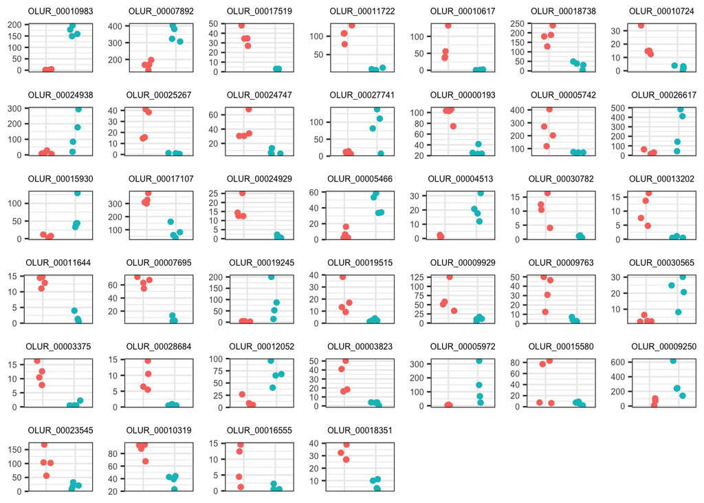

```r
juv.DB.p05.names <-rownames(diffex.juv.DB[order(diffex.juv.DB$padj),])

count_plots.juv.DB = list()
#plot the 39 genes with lowest p-values
for (i in 1:39) {
a <-  plotCounts(dds.juv.DESeq, gene=juv.DB.p05.names[i], intgroup=c("population", "pCO2.parent"), returnData = TRUE)
b <- ggplot(subset(a, population=="Dabob Bay") %>% rownames_to_column("sample") %>%
              mutate(sample=gsub("_juvenile", "", sample)),
       aes(x=pCO2.parent, y=count, color=pCO2.parent, label=sample)) +
  geom_point(position=position_jitter(w = 0.2,h = 0)) +
    #geom_text(size=3) +
    theme_bw() +
    ggtitle(juv.DB.p05.names[i]) +
    theme(plot.title = element_text(hjust = 0.5, size = 6), axis.text.x = element_blank(),
          axis.text.y = element_text(size=6),
          axis.title = element_blank(), axis.ticks.x = element_blank(), legend.position = "none")
count_plots.juv.DB[[i]] <- b
}

plot_grid(plotlist=count_plots.juv.DB) #plot them in a grid
```

```r
#count_plots.juv.DB #plot them all individually
```

# GO Enrichment Analysis

Extract GO terms for genes that are deferentially expressed in FB

```r
# load(file = "../references/Olurida_gene_uniprot") #object = Olurida_gene_uniprot
#
# # All genes in FB (background)
# res.juv.FB %>% as.data.frame() %>% rownames_to_column("gene") %>% select(gene, padj) %>%
#   left_join(Olurida_gene_uniprot %>% select(Name, SPID), by = c("gene"="Name")) %>%
#   select(SPID) %>%  na.omit() %>% unlist() %>% as.vector() %>% write_clip()
#
# # DEG in FB
# diffex.juv.FB %>% as.data.frame() %>% rownames_to_column("gene") %>% select(gene, padj) %>%
#   left_join(Olurida_gene_uniprot %>% select(Name, SPID), by = c("gene"="Name")) %>%
#   select(SPID) %>%  na.omit() %>% unlist() %>% as.vector() %>% write_clip()
```

Extract GO terms for genes that are deferentially expressed in DB

```r
#load(file = "../references/Olurida_gene_uniprot") #object = Olurida_gene_uniprot

# All genes in DB (background)
# res.juv.DB %>% as.data.frame() %>% rownames_to_column("gene") %>% select(gene, padj) %>%
#   left_join(Olurida_gene_uniprot %>% select(Name, SPID), by = c("gene"="Name")) %>%
#   select(SPID) %>%  na.omit() %>% unlist() %>% as.vector() %>% write_clip()
#
# # DEG in DB
# diffex.juv.DB %>% as.data.frame() %>% rownames_to_column("gene") %>% select(gene, padj) %>%
#   left_join(Olurida_gene_uniprot %>% select(Name, SPID), by = c("gene"="Name")) %>%
#   select(SPID) %>%  na.omit() %>% unlist() %>% as.vector() %>% write_clip()
```

- protein ubiquitination
- cellular protein localization
- protein K48-linked ubiquitination
- protein ubiquitination involved in ubiquitin-dependent protein catabolic process
- protein K63-linked ubiquitination
- proteasomal protein catabolic process